# Homework 3 - Design and Analysis of Algorithms - Naiara Alonso Montes

## Problem 1

*Find a legal flow from $s$ to $t$ in the following network with upper and lower limits. (You don't have to specificy all the steps in the Ford-Flukerson or Edmonds-Karp algorithm that you are using, but you have to explain the construction and the resulting flow.)*

I will write down the steps by Ford-Flukerson algorithm used to proof that there exists a legal flow in the following graph $\tilde{N}$.

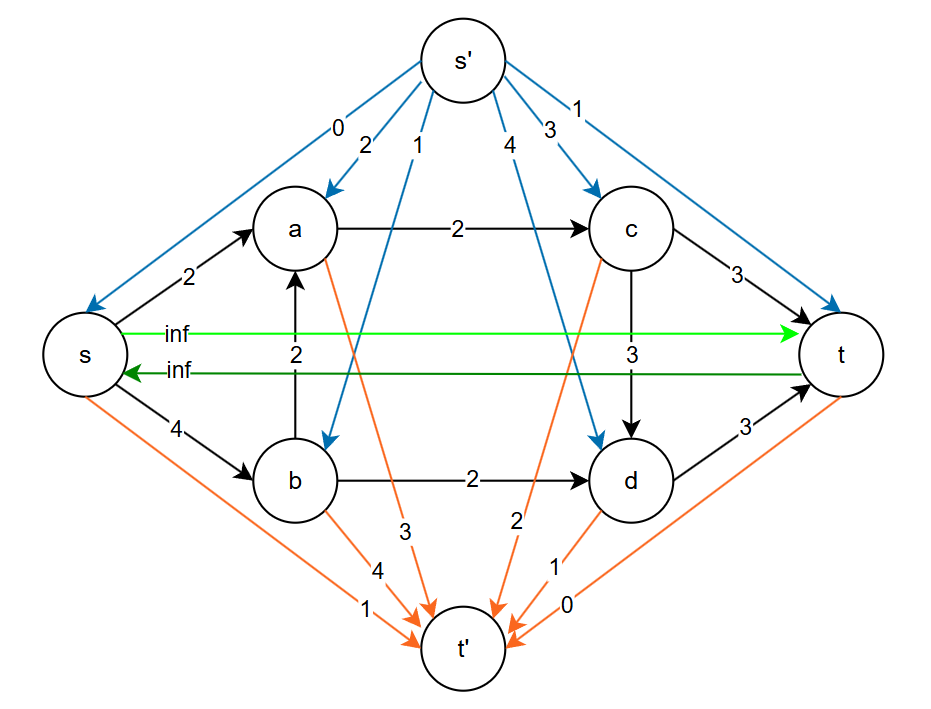

**DBS**

- s' -> a -> t', bottleneck = 2, flow = 2
- s' -> b -> t', bottleneck = 1, flow = 3
- s' -> c -> t', bottleneck = 2, flow = 5
- s' -> d -> t', bottleneck = 1, flow = 6
- s' -> t -> s -> a -> t', bottleneck = 1, flow = 7
- s' -> c -> t -> s -> t', bottleneck = 1, flow = 8
- s' -> d -> t -> s -> b -> t', bottleneck = 3, flow = 11

At the end of this iterations the resulting network is:

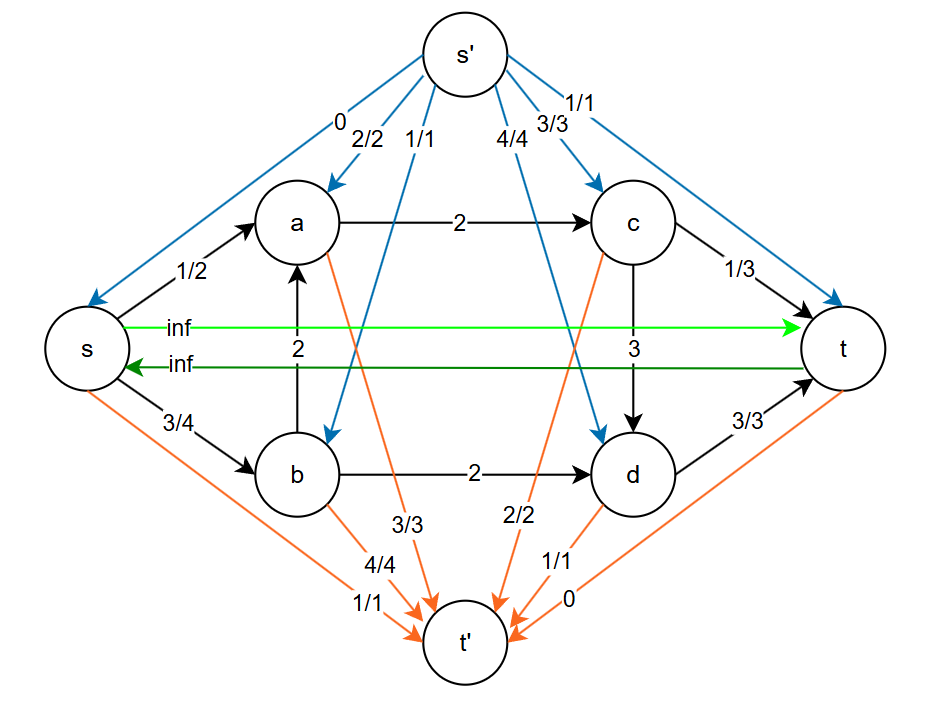

By a theorem used in class, if all edges from leaving from s' are collapsed, there exists a legal flow in network $\tilde{N}$.

*Find a maximum flow in the network in part (a). Show all the minimum cuts.*

This is the original graph with the flow found in $\tilde{N}$:

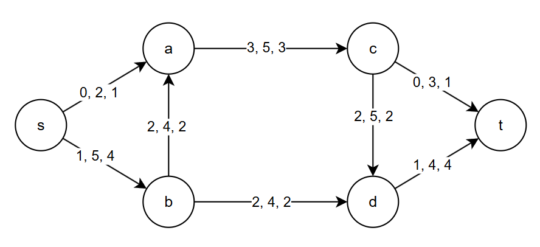

This graph meets the vertex and edges rule, but still it is not maximum flow. we can increase the flow by pushing one unit of flow using edge $\{s,a\}$ and $\{s, b\}$:

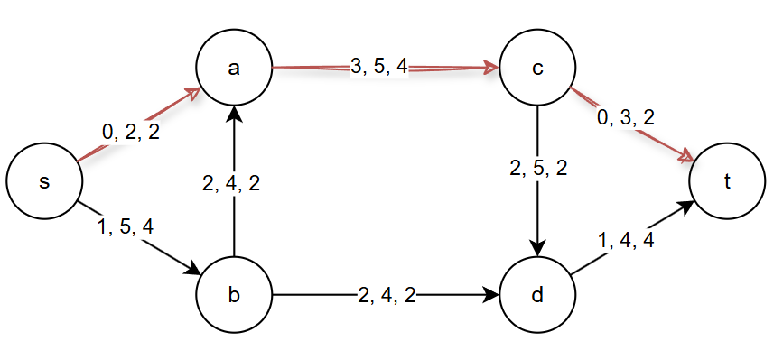

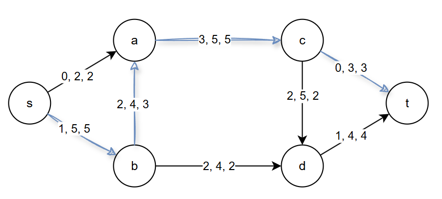

With this, all edges leaving $s$ are saturated, so the **maximum flow for this graph is 7**.

A searching for all possible min-cut is tedious, I created this Python program that iterates all possible combinations of nodes in a cut an computes its value. All the min-cuts are display as the result of the iteration. This graph has in total **10 min-cuts**.

```python
from itertools import combinations

s = [(0, 0), (0, 2), (1, 5), (0, 0), (0, 0), (0, 0)]
a = [(0, 0), (0, 0), (0, 0), (3, 5), (0, 0), (0, 0)]
b = [(0, 0), (2, 4), (0, 0), (0, 0), (2, 4), (0, 0)]
c = [(0, 0), (0, 0), (0, 0), (0, 0), (2, 5), (0, 3)]
d = [(0, 0), (0, 0), (0, 0), (0, 0), (0, 0), (1, 4)]
t = [(0, 0), (0, 0), (0, 0), (0, 0), (0, 0), (0, 0)]

edges = [s, a, b, c, d, t]

MAX_FLOW = 7

nodes = ['s', 'a', 'b', 'c', 'd', 't']


def all_possible_cuts(nodes):
  all_combinations = []
  for r in range(0, len(nodes)):
    for comb in combinations(nodes, r):
      all_combinations.append(comb)
  return all_combinations

def min_cut(edges, nodes):
    all_cuts = all_possible_cuts(nodes)
    min_cuts = []
    min_cut_value = float('inf')

    for cut in all_cuts:
      nodes_index_in_cut = [nodes.index(node) for node in cut]

      nodes_in_cut = [nodes[i] for i in nodes_index_in_cut]

      nodes_index = [nodes.index(node) for node in nodes_in_cut]

      capacity = 0
      lower_bound = 0
      for node in nodes_index:
          columns = [edge[node] for edge in edges]
          row = edges[node]
          for i, edge in enumerate(row):
            if i not in nodes_index: # node not in cut
              capacity += edge[1]
          for i, column in enumerate(columns):
              if i not in nodes_index: # node not in cut
                  lower_bound += column[0]
      if capacity - lower_bound == MAX_FLOW:
        min_cuts.append(cut)

    return min_cuts

min_cut(edges, nodes)
```

```
[('s',),
 ('b',),
 ('s', 'd'),
 ('s', 'a', 't'),
 ('a', 'b', 't'),
 ('b', 'c', 'd'),
 ('s', 'a', 'b', 'd'),
 ('s', 'a', 'c', 't'),
 ('a', 'b', 'c', 't'),
 ('s', 'a', 'b', 'c', 'd')]
```

## Problem 2

*(a) What is the minimum number of points we need to use? Explain.*

The minimum number of points to be used is **4**, as it is the result of the degree of $C(x) + 1$

\begin{equation} M_4(ω) = \begin{pmatrix} 1 & 1 & 1 & 1 \\ 1 & ω & ω^2 & ω^3 \\ 1 & ω^2 & 1 & ω^2 \\ 1 & ω^3 & ω^2 & ω \\ \end{pmatrix} = \begin{pmatrix} 1 & 1 & 1 & 1 \\ 1 & i & -1 & -i \\ 1 & -1 & 1 & -1 \\ 1 & -i & -1 & i \end{pmatrix} \end{equation}

\begin{equation} a = \begin{pmatrix} 1 & 2 & 2 & 0 \end{pmatrix} \end{equation}

\begin{equation} b = \begin{pmatrix} -2 & 1 & 0 & 0 \end{pmatrix} \end{equation}

*Evaluate $A(x)$ at the complex 4th roots of unity. Show at least one level of recursion.*

\begin{equation} \begin{pmatrix} A(1) & = & A(1) \\ A(i) & = & A(ω) \\ A(-1) & = & A(ω^2) \\ A(-i) & = & A(ω^3) \end{pmatrix} = M(i) ⋅ a^T = \begin{pmatrix} 1 & 1 & 1 & 1 \\ 1 & i & -1 & -i \\ 1 & -1 & 1 & -1 \\ 1 & -i & -1 & i \end{pmatrix} ⋅ \begin{pmatrix} 1 \\ 2 \\ 2 \\ 0 \\ \end{pmatrix} = \end{equation}

\begin{equation} \begin{pmatrix} 1 & 1 \\ 1 & -1 \\ 1 & 1 \\ 1 & -1 \end{pmatrix} ⋅ \begin{pmatrix} 1 \\ 2 \end{pmatrix} + \begin{pmatrix} 1 & 1 \\ i & -i \\ -1 & -1 \\ -i & i \end{pmatrix} ⋅ \begin{pmatrix} 2 \\ 0 \end{pmatrix} = \begin{pmatrix} 1 ⋅ 1 + 1 ⋅ 2 \\ 1 ⋅ 1 + (-1) ⋅ 2 \\ 1 ⋅ 1 + 1 ⋅ 2 \\ 1 ⋅ 1 + (-1) ⋅ 2 \\ \end{pmatrix} + \begin{pmatrix} 1 ⋅ 2 + 1 ⋅ 0 \\ i ⋅ 2 + (-i) ⋅ 0 \\ -1 ⋅ 2 + (-1) ⋅ 0 \\ -i ⋅ 2 + i ⋅ 0 \\ \end{pmatrix} = \begin{pmatrix} 3 \\ -1 \\ 3 \\ -1 \end{pmatrix} + \begin{pmatrix} 2 \\ 2i \\ -2 \\ -2i \end{pmatrix} = \begin{pmatrix} 5 \\ -1 + 2i \\ 1 \\ -1 -2i \end{pmatrix} \end{equation}

*Evaluate $B(x)$ at the complex 4th roots of unity. Show at least one level of recursion.*

\begin{equation} \begin{pmatrix} B(1) & = & B(1) \\ B(i) & = & B(ω) \\ B(-1) & = & B(ω^2) \\ B(-i) & = & B(ω^3) \end{pmatrix} = M(i) ⋅ b^T = \begin{pmatrix} 1 & 1 & 1 & 1 \\ 1 & i & -1 & -i \\ 1 & -1 & 1 & -1 \\ 1 & -i & -1 & 1 \end{pmatrix} ⋅ \begin{pmatrix} -2 \\ 1 \\ 0 \\ 0 \\ \end{pmatrix} \end{equation}

\begin{equation} \begin{pmatrix} 1 & 1 \\ 1 & -1 \\ 1 & 1 \\ 1 & -1 \end{pmatrix} ⋅ \begin{pmatrix} -2 \\ 0 \end{pmatrix} + \begin{pmatrix} 1 & 1 \\ i & -i \\ -1 & -1 \\ -i & i \end{pmatrix} ⋅ \begin{pmatrix} 1 \\ 0 \end{pmatrix} = \begin{pmatrix} 1 ⋅ (-2) + 1 ⋅ 0 \\ 1 ⋅ (-2) + (-1) ⋅ 0 \\ 1 ⋅ (-2) + 1 ⋅ 0 \\ 1 ⋅ (-2) + (-1) ⋅ 0 \\ \end{pmatrix} + \begin{pmatrix} 1 ⋅ 1 + 1 ⋅ 0 \\ i ⋅ 1 + (-i) ⋅ 0 \\ -1 ⋅ 1 + (-1) ⋅ 0 \\ -i ⋅ 1 + i ⋅ 0 \\ \end{pmatrix} = \begin{pmatrix} -2 \\ -2 \\ -2 \\ -2 \end{pmatrix} + \begin{pmatrix} 1 \\ i \\ -1 \\ -i \end{pmatrix} = \begin{pmatrix} -1 \\ -2 + i \\ -3 \\ -2 -i \end{pmatrix} \end{equation}

*Compute $C(x)$ at the complex 4th roots of unity*

\begin{equation} \begin{pmatrix} C(1) \\ C(ω) \\ C(ω^2) \\ C(ω^3) \end{pmatrix} = \begin{pmatrix} 5 & ⋅ & (-1) \\ (-1 + 2i) & ⋅ & (-2+i) \\ 1 & ⋅ & (-3) \\ (-1-2i) & ⋅ & (-2-i) \\ \end{pmatrix} = \begin{pmatrix} -5 \\ -5i \\ -3 \\ 5i \end{pmatrix} \end{equation}

*Find the coefficients of $C(x)$*

\begin{equation} \begin{pmatrix} C(ω^0) \\ C(ω^1) \\ C(ω^2) \\ C(ω^3) \\ \end{pmatrix} = M_n(ω) ⋅ c^T ⇒ c^T = \frac{1}{n}⋅M_n(ω^{-1}) \end{equation}

\begin{equation} c^T = \frac{1}{4} \begin{pmatrix} 1 & 1 & 1 & 1 \\ 1 & -i & -1 & i \\ 1 & -1 & 1 & -1 \\ 1 & i & -1 & -i \end{pmatrix} ⋅ \begin{pmatrix} -5 \\ -5i \\ -3 \\ 5i \\ \end{pmatrix} = \frac{1}{4} ⋅ \begin{pmatrix} 1 & 1 \\ 1 & -1 \\ 1 & 1 \\ 1 & -1 \end{pmatrix} ⋅ \begin{pmatrix} -5 \\ -3 \end{pmatrix} + \begin{pmatrix} 1 & 1 \\ -i & i \\ -1 & -1 \\ i & -i \end{pmatrix} ⋅ \begin{pmatrix} -5i \\ 5i \end{pmatrix} = \frac{1}{4} ⋅ \begin{pmatrix} -8 \\ -2 \\ -8 \\ -2 \end{pmatrix} + \begin{pmatrix} 0 \\ -10 \\ 0 \\ 10 \end{pmatrix} = \frac{1}{4} ⋅ \begin{pmatrix} -8 \\ -12 \\ -8 \\ 8 \end{pmatrix} = \begin{pmatrix} -2 \\ -3 \\ -2 \\ 2 \end{pmatrix} \end{equation}

\begin{equation} C(x) = 2x^3 -2x^2-3x - 2 \end{equation}

## Problem 3

The matrix $A$ is a circulant matrix which means that each row is a cyclic shift of the previous row. The product of $A⋅b^T$ can be interpreted as the circular convolution of the first row of $A$ and the vector $b$. The structure of $A$ allows to use the Fasr Fourier Transform.

**Algorithm**

1. Calulate the FFT for the first row of $A$.
2. Calculate the FFT of $b$.
3. Multiply the FFT of first row of $A$ and the FFT of $b$
4. Calculate the inverse FFT of the multiplication result.

**Complexity**

Each FFT use has a complexity of $O(n\log n)$, we are using 3 so it would be $3⋅O(n \log n)$, but the constant is discarded, so the final complexity for the algorithm is $O(n \log n)$.

**Correctness**

1. By this [paper](https://web.mit.edu/18.06/www/Spring17/Circulant-Matrices.pdf), "multiplying by a circulant matriz is equivalent to ... operation called circular convolution".
2. By this other [publication](https://cas.minesparis.psl.eu/~chaplais/Wavetour_presentation/transformees/Fourier/FFTUS.html), "The circular convolution is itself computed by performing the FFT of the two signals, computing their product and then its inverse FFT".

```python
!jupyter nbconvert --to html HW3.ipynb
```